# Prectical Machine Learning project

Sergey Smirnov

October 4, 2017

## Background

Using devices such as Jawbone Up, Nike FuelBand, and Fitbit it is now possible to collect a large amount of data about personal activity relatively inexpensively. These type of devices are part of the quantified self movement - a group of enthusiasts who take measurements about themselves regularly to improve their health, to find patterns in their behavior, or because they are tech geeks. One thing that people regularly do is quantify how much of a particular activity they do, but they rarely quantify how well they do it. In this project, your goal will be to use data from accelerometers on the belt, forearm, arm, and dumbell of 6 participants. They were asked to perform barbell lifts correctly and incorrectly in 5 different ways. More information is available from the website here: http://groupware.les.inf.puc-rio.br/har (see the section on the Weight Lifting Exercise Dataset).

## Data

The training data for this project are available here:

https://d396qusza40orc.cloudfront.net/predmachlearn/pml-training.csv

The test data are available here:

https://d396qusza40orc.cloudfront.net/predmachlearn/pml-testing.csv

The data for this project come from this source: http://groupware.les.inf.puc-rio.br/har. If you use the document you create for this class for any purpose please cite them as they have been very generous in allowing their data to be used for this kind of assignment.

## Goal

The goal of your project is to predict the manner in which they did the exercise. This is the “classe” variable in the training set. You may use any of the other variables to predict with. You should create a report describing how you built your model, how you used cross validation, what you think the expected out of sample error is, and why you made the choices you did. You will also use your prediction model to predict 20 different test cases.

## Loading Data

```r
train_url <- "https://d396qusza40orc.cloudfront.net/predmachlearn/pml-training.csv"
download.file(url=train_url, destfile="training.csv")

test_url <- "https://d396qusza40orc.cloudfront.net/predmachlearn/pml-testing.csv"
download.file(url=test_url, destfile="testing.csv")

#read in training and testing data
Training <- read.csv("training.csv", na.strings=c("NA","#DIV/0!",""))
Testing  <- read.csv("testing.csv", na.strings=c("NA","#DIV/0!",""))
```

Distribution of the outcome column we want to predict:

```r
summary(Training$classe)#this is the outcome we want to predict
```

```
##    A    B    C    D    E
## 5580 3797 3422 3216 3607
```

Partitioning the training data onto Training and Validation sets.

```r
inTrain <- createDataPartition(y=Training$classe, p=0.6, list=FALSE)
Train <- Training[inTrain, ]
Valid <- Training[-inTrain, ]

dim(Train)
```

```
## [1] 11776   160
```

```r
dim(Valid)
```

```
## [1] 7846  160
```

## Cleaning Data

First 7 columns are clearly not predictors

```r
Train <- Train[, 8:length(Train)]
Valid <- Valid[, 8:length(Valid)]
```

Remove variables with near zero variance

```r
NZV <- nearZeroVar(Train)
Train <- Train[, -NZV]
Valid <- Valid[, -NZV]
```

Remove variables with more that 75% or NAs

```r
tmpNA <- sapply(Train, function(x) mean(is.na(x))) > 0.75
Train <- Train[, tmpNA == F]
Valid <- Valid[, tmpNA == F]
```

```r
dim(Train)
```

```
## [1] 11776    53
```

```r
dim(Valid)
```

```
## [1] 7846   53
```

## Decision Trees model

Bulid the model

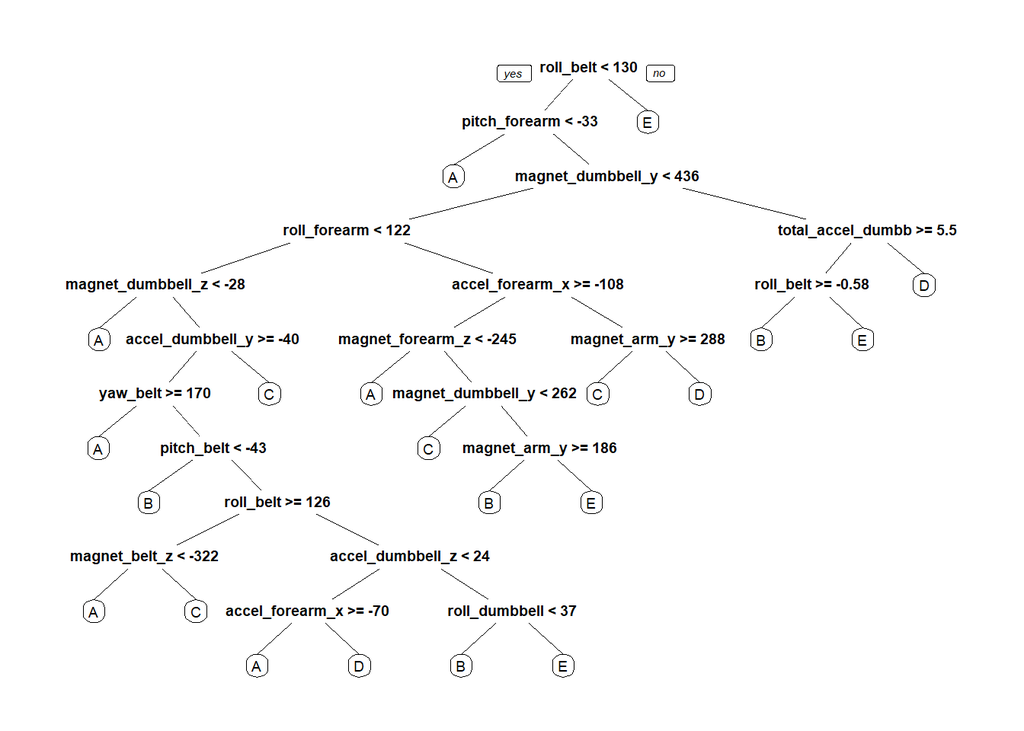

```r
set.seed(12345)

modelTree <- rpart(classe ~ ., data = Train, method = "class")
# print(modelTree)
prp(modelTree)
```

Cross validation on validation data

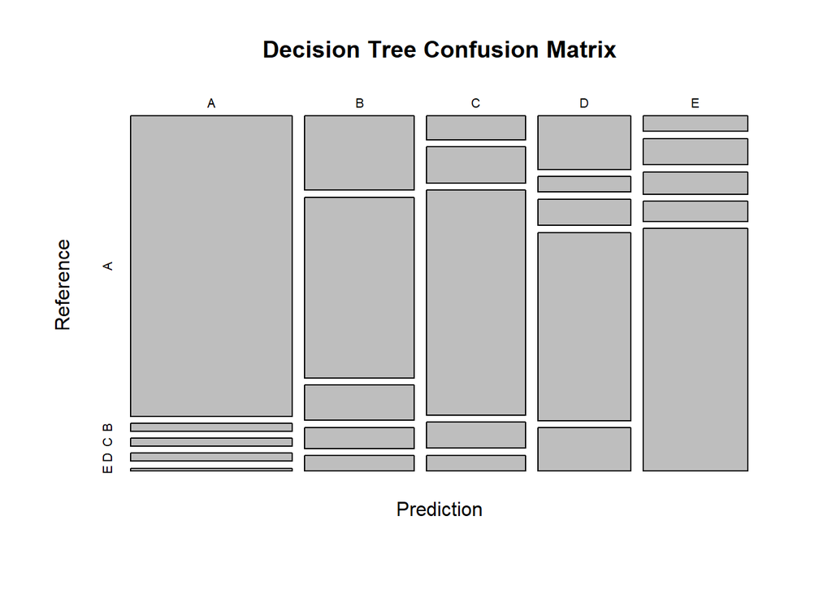

```r
predictTree <- predict(modelTree, Valid, type = "class")
cm <- confusionMatrix(Valid$classe, predictTree)

plot(cm$table, col = cm$classe, main = "Decision Tree Confusion Matrix")
```

Model accuracy and out of sample error

```r
cm$overall['Accuracy']
```

```
##  Accuracy
## 0.7196023
```

## Random Forest model

Bulid the model

```r
set.seed(12345)

modelRF <- randomForest(classe~., data = Train)
#print(modelRF)
```

Cross validation on validation data

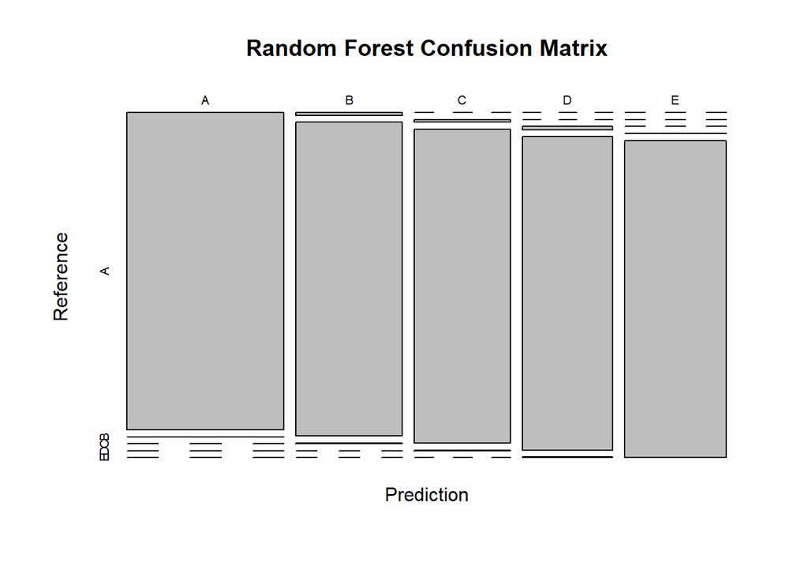

```r
predictRF <- predict(modelRF, Valid, type = "class")
cm <- confusionMatrix(Valid$classe, predictRF)

plot(cm$table, col = cm$classe, main = "Random Forest Confusion Matrix")
```

Model accuracy and out of sample error

```r
cm$overall['Accuracy']
```

```
##  Accuracy
## 0.9937548
```

## Run model against Testing data

```r
predictTest <- predict(modelRF, Testing, type = "class")
print(predictTest)
```

```
##  1  2  3  4  5  6  7  8  9 10 11 12 13 14 15 16 17 18 19 20
##  B  A  B  A  A  E  D  B  A  A  B  C  B  A  E  E  A  B  B  B
## Levels: A B C D E
```